# Homework Assignment 1

Jason Thompson

Assigned: Oct 24, 2020, Due Sun Nov 01, 2020 11:59PM

## HW-1 Instructions

> Our class emphasizes clear communication of data analysis results to non-technical audiences. I expect your HTML output documents to be readable and well formatted. I expect you to put ample comments in your R code to make the code understandable. Along with accuracy of results, I am looking for quality of presentation as well. This homework is due by **11:59PM on Nov 01st**. To complete this assignment, follow these steps:
1. Create a new RStudio Project for this HW. Sync the project directory with a GitHub Repository (see instructions on Canvas on how to do that).
2. Download the `HW1.Rmd` file from Canvas. Save the file in the RStudio Project Directory.
3. Open `HW1.Rmd` in RStudio. Replace the “Your Name Here” text in the `author:` field with your name.
4. Supply your solutions to the homework by editing `HW1.Rmd`.
5. Run your code in the Console and Knit HTML frequently to check for errors.
6. You may find it easier to solve a problem by interacting only with the Console at first.
7. When you have completed the homework please check that your knits correctly when you click `Knit HTML`.
8. “Push” all your local changes to the GitHub Repo for the project.
9. Submit your RMD file, the HTML output and a link to your GitHub Repo on Canvas.

## Data frame basics

We will continue working with the nycflights dataset we looked at in class. **Please be sure to keep the data file in the same directory as the RMD file - your project directory.**

First - make sure that you are reading the data correctly and doing all the data cleaning steps that we did in class. Feel free to go beyond our class work in cleaning the data if you feel the need.

```r
# Reading the nycflights data
nycfl <- read.csv("nycflights.csv")

# Deleting the column x
nycfl$X <- NULL

# Factorize columns that need to be a factor
nycfl$origin <- as.factor(nycfl$origin)
nycfl$tailnum <- as.factor(nycfl$tailnum)
nycfl$month <- as.factor(nycfl$month)
nycfl$dest <- as.factor(nycfl$dest)
nycfl$carrier <- as.factor(nycfl$carrier)
nycfl$flight <- as.factor(nycfl$flight)
```

I now would like you to answer the following - all in their own separate R code blocks.

### Data Exploration

Let’s first do some simple exploration of this data.

- How many airlines are there? (Hint: `levels` and `length` can be useful here)

  ```r
  # Levels provides the unique factors and length computes the number of those unique factors
  length(levels(nycfl$carrier))
  ```

  ```
  ## [1] 16
  ```

  There are 16 airlines.
- How many flights there were by the airline with code `OO`? (Hint: `nrow` can be useful here along with logical indexing)

  ```r
  # The logical indexing finds the rows where the carrier is OO and nrow sums the number of rows meeting that condition
  nrow(nycfl[nycfl$carrier == "OO", ])
  ```

  ```
  ## [1] 32
  ```

  There were 32 flights by the airline with code `OO`.
- How long is the shortest flight out of any NYC airport? (Hint: `min` can be useful, remember to handle `NA` values)

  ```r
  # Find the minimum air time while ignoring NA values
  min(nycfl$air_time, na.rm = TRUE)
  ```

  ```
  ## [1] 20
  ```

  The shortest flight out of any NYC airport is 20 minutes.
- How many flights were there by United Airlines (code: UA) on Jan 12th 2013?

  ```r
  # Logical index looking for where carrier is UA and the date components are month 1, day 12, year 2013. nrow then counts the number of rows meeting these conditions
  nrow(nycfl[(nycfl$carrier == "UA") & (nycfl$year == 2013) & (nycfl$month == "1") & (nycfl$day == 12), ])
  ```

  ```
  ## [1] 112
  ```

  There were 112 flights by United Airlines on January 12, 2013.

### Arrival Delay

Lets focus on Arrival Delay.

- What was the average arrival delay for all airports and all airlines combined in Jan 2013?

  ```r
  # Finds the rows corresponding to January 2013 and the column corresponding to arrival delay and takes the average, ignoring NA values
  mean(nycfl[(nycfl$year == 2013) & (nycfl$month == "1"), "arr_delay"], na.rm = TRUE)
  ```

  ```
  ## [1] 6.129972
  ```

  The average arrival delay for all airports and all airlines combined in January 2013 was 6.13 minutes.
- Whats was the median arrival delay for all airports and all airlines combined in Jan 2013?

  ```r
  # Finds the rows corresponding to January 2013 and the column corresponding to arrival delay and finds the median, ignoring NA values
  median(nycfl[(nycfl$year == 2013) & (nycfl$month == "1"), "arr_delay"], na.rm = TRUE)
  ```

  ```
  ## [1] -3
  ```

  The median arrival delay for all airports and all airlines combined in January 2013 was -3 minutes.

Based on your answers to the two questions above, what can you say about the distribution of arrival delays? Provide your answer in a text paragraph form.

Seeing as the mean of 6.13 minutes is greater than the median of -3 minutes, the distribution of arrival delays is right skewed. Also, it can be seen that more than half of the flights arrived early in January 2013 as the median is negative.

### Airline Performance

Lets see if all airlines are equally terrible as far as flight arrival delays are concerned. For this question you will have to make sure that airline column is coded as a factor.

- Calculate average arrival delays by airline (Hint: look up the command `tapply`)

  ```r
  # Computes the mean arrival dely by airline, ignoring NA values
  tapply(nycfl$arr_delay, nycfl$carrier, mean, na.rm = TRUE)
  ```

  ```
  ##         9E         AA         AS         B6         DL         EV         F9
  ##  7.3796692  0.3642909 -9.9308886  9.4579733  1.6443409 15.7964311 21.9207048
  ##         FL         HA         MQ         OO         UA         US         VX
  ## 20.1159055 -6.9152047 10.7747334 11.9310345  3.5580111  2.1295951  1.7644644
  ##         WN         YV
  ##  9.6491199 15.5569853
  ```

- Draw a Bar Plot of Average Arrival Delays for all the Airlines (Hint: command for making a Bar Plot is simply `barplot`)

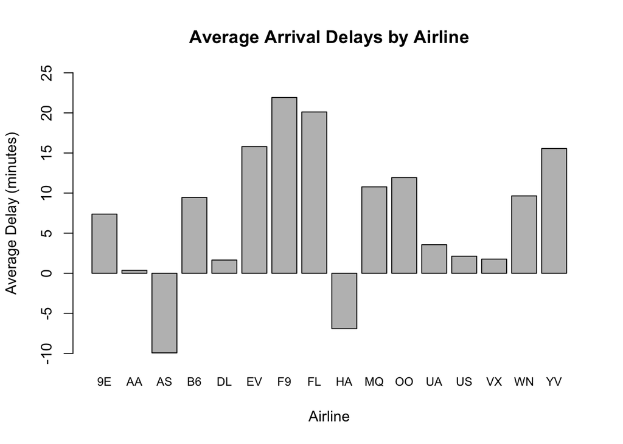

  ```r
  avgArrDelAirline <- tapply(nycfl$arr_delay, nycfl$carrier, mean, na.rm = TRUE)
  barplot(avgArrDelAirline, main = "Average Arrival Delays by Airline", xlab = "Airline", ylab = "Average Delay (minutes)", ylim = c(-10, 25), cex.names = 0.8)
  ```

- Which airline has the highest average arrival delay? Which airline has the smallest average arrival delay? Are there airlines that actually have negative average delay? Provide answer to this question in a text paragraph form using **inline R code**.  
  The airline with the highest average arrival delay is F9. The airline with the smallest average arrival delay is AS. The airlines with negative average arrival delays are AS, HA.

### Air Gain

Create a new column named airgain such that airgain = (departure delay - arrival delay): this is the amount of delay a flight made up while in air.

```r
# Computes the airgain for each flight
nycfl$airgain <- (nycfl$dep_delay - nycfl$arr_delay)
```

1. Explore airgain data - calculate suitable descriptive statistics and appropriate graphics to better understand this data. This part is open ended - you do what you feel works best for you.

   ```r
   # Computes the average airgain
   avgAirgain = mean(nycfl$airgain, na.rm = TRUE)
   medAirgain = median(nycfl$airgain, na.rm = TRUE)

   # Computes number of flights with departure delay
   numFlWDepDelay <- nrow(nycfl[nycfl$dep_delay > 0, ])

   # Computes number of flights with departure delay and airgain
   numFlWDepDelayAirgain <- nrow(nycfl[(nycfl$dep_delay > 0) & (nycfl$airgain > 0), ])

   # Computes number of flights with departure delay, airgain, and no arrival delay
   numFlWDepDelAirgainNoArrDel <- nrow(nycfl[(nycfl$dep_delay > 0) & (nycfl$airgain > 0) & (nycfl$arr_delay <= 0), ])

   # Compute average airgain by airline
   avgAirgainAirline <- tapply(nycfl$airgain, nycfl$carrier, mean, na.rm = TRUE)
   # Compute average distance by airline
   avgDistAirline <- tapply(nycfl$distance, nycfl$carrier, mean, na.rm = TRUE)
   ```

   The average airgain across airlines was 5.66 minutes with a median airgain of 7 minutes. The average airgain by airline is shown in a plot below.  
   In this dataset, 40.6% of flights had a departure delay. Of the delayed flights, 67.8% of them made up time in the air. Additionally, of the flights with a departure delay, 32.5% of them had no arrival delay or arrived early, meaning the airgain was sufficient to ensure an on-time or early arrival.

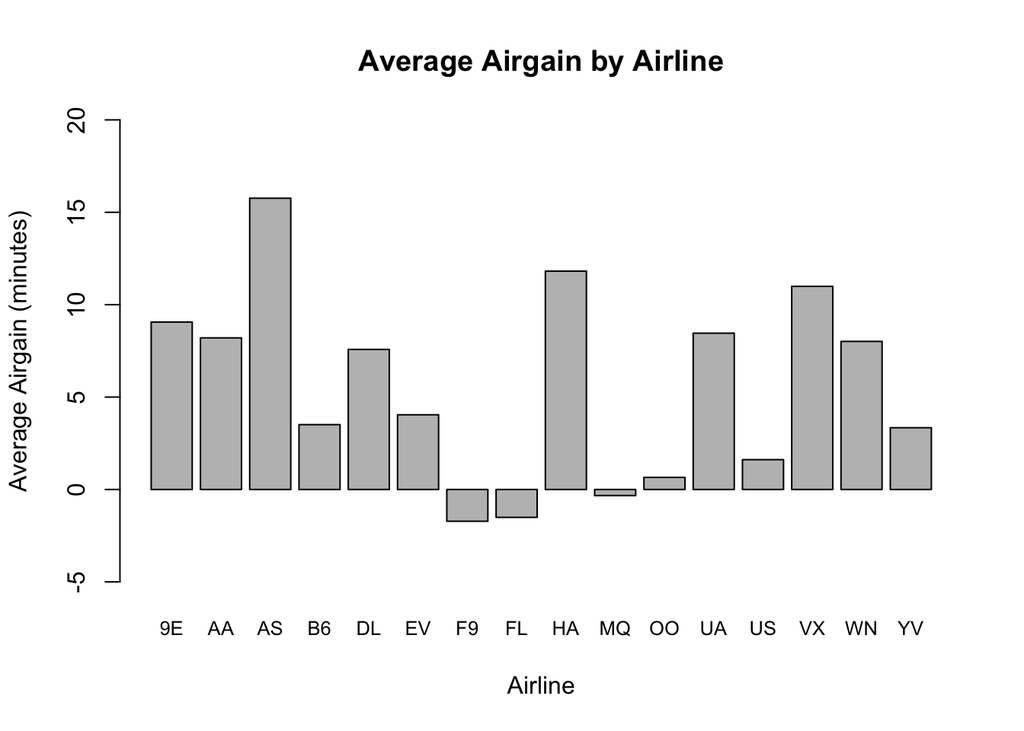

   ```r
   barplot(avgAirgainAirline, main = "Average Airgain by Airline", xlab = "Airline", ylab = "Average Airgain (minutes)", cex.names = 0.8, ylim = c(-5, 20))
   ```

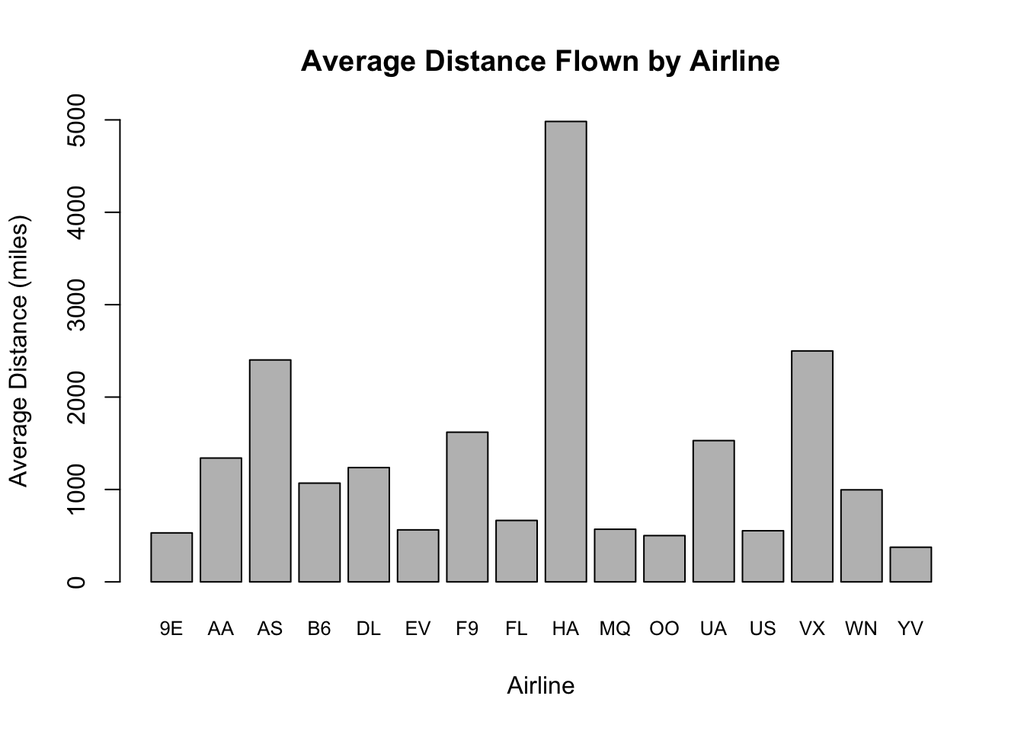

   ```r
   barplot(avgDistAirline, main = "Average Distance Flown by Airline", xlab = "Airline", ylab = "Average Distance (miles)", cex.names = 0.8, ylim = c(0, 5000))
   ```

   From the Average Airgain by Airline and Average Distance Flown by Airline plots, one can see that the three airlines with the largest average airgains also fly the longest average distances. Intuitively, this makes sense as flying a longer distance allows more opportunity to make time up.
2. Answer the questions:
- do airlines actually gain any time when in air on average?  
  Based on the average airgain across airlines of 5.66 minutes, airlines do actually gain time when in the air on average. Also, in the Average Airgain by Airline plot above, one can see that most airlines have a positive airgain.
- Calculate average airgain for different airlines - which airlines do a better job, which do a worse job?

  ```r
  # Repeated from above
  tapply(nycfl$airgain, nycfl$carrier, mean, na.rm = TRUE)
  ```

  ```
  ##         9E         AA         AS         B6         DL         EV         F9
  ##  9.0599052  8.2048393 15.7616361  3.5095746  7.5796089  4.0424982 -1.7195301
  ##         FL         HA         MQ         OO         UA         US         VX
  ## -1.5099213 11.8157895 -0.3293526  0.6551724  8.4588972  1.6150976 10.9921814
  ##         WN         YV
  ##  8.0125374  3.3419118
  ```

  Average Airgain by Airline is plotted above. Most airlines have a positive average airgain, with AS, HA, and VX having the largest average airgains. F9, FL, and MQ have negative average airgains, meaning that they often lose time in the air. Some of the success and failure surrounding airgains could potentially be attributed to the average distance that these airlines fly. Flying a larger distance allows more opportunity to make up time in the air, and the opposite is true for shorter flights.

### Merging Data Frames

> This section and the next is new compared to the class exercise. As you had an opportunity to work together in your breakout rooms for previous questions, this and the next section will carry a higher weight in grading for this HW.

You can get detailed information about the physical planes in our dataset in this file: `planes.csv`. Download and save this file in your project directory.

1. Read the `planes.csv` file using `read.csv` command. Do any data cleaning necessary.

   ```r
   # Reads in the planes data set
   plane <- read.csv("planes.csv")
   plane$X <- NULL

   # Factorizes columns that need to be a factor
   plane$tailnum <- as.factor(plane$tailnum)
   plane$type <- as.factor(plane$type)
   plane$manufacturer <- as.factor(plane$manufacturer)
   plane$model <- as.factor(plane$model)
   plane$engines <- as.factor(plane$engines)
   plane$engine <- as.factor(plane$engine)
   plane$speed <- as.factor(plane$speed)
   plane$seats <- as.factor(plane$seats)

   # Reduce manufacturer list using common names
   levels(plane$manufacturer)[levels(plane$manufacturer)=="AIRBUS INDUSTRIE"] <- "AIRBUS"
   levels(plane$manufacturer)[levels(plane$manufacturer)=="CANADAIR LTD"] <- "CANADAIR"
   levels(plane$manufacturer)[levels(plane$manufacturer)=="MCDONNELL DOUGLAS AIRCRAFT CO"] <- "MCDONNELL DOUGLAS"
   levels(plane$manufacturer)[levels(plane$manufacturer)=="MCDONNELL DOUGLAS CORPORATION"] <- "MCDONNELL DOUGLAS"
   ```

2. Merge the flights data and the planes data using the `merge` command. You should do the merge on the common column named `tailnum`. *getting this right may need some trial and error and getting some help*.

   ```r
   # Merges the flight and plane datasets using the tailnum column
   nycPlane <- merge(nycfl, plane, by = "tailnum")
   ```

3. Now that you have a merged dataset, think of what interesting questions that you can ask that can be answered using the merged dataset. You are asked to pose five interesting questions and answer them. (For example: who are the top 10 manufacturers of planes that fly out of NYC airports?) **Be creative. Be bold. Ask questions that you would want to know answers to even if you were not doing this for a HW.**  
   c.1) What percent of the flights out of NYC are on aircraft that is 10 years or older?

   ```r
   # Computes the age of the aircraft in 2013
   aircraftAge = 2013 - nycPlane$year.y
   # Adds the number of instances when the flight's aircraft was 10 years or older
   numAircraft10Older = sum(aircraftAge>=10, na.rm = TRUE)
   ```

   61.2% of flights out of NYC are on an aircraft that is 10 years or older.  
   c.2) What is the average distance of a flight from NYC grouped by airplane seating capacity?

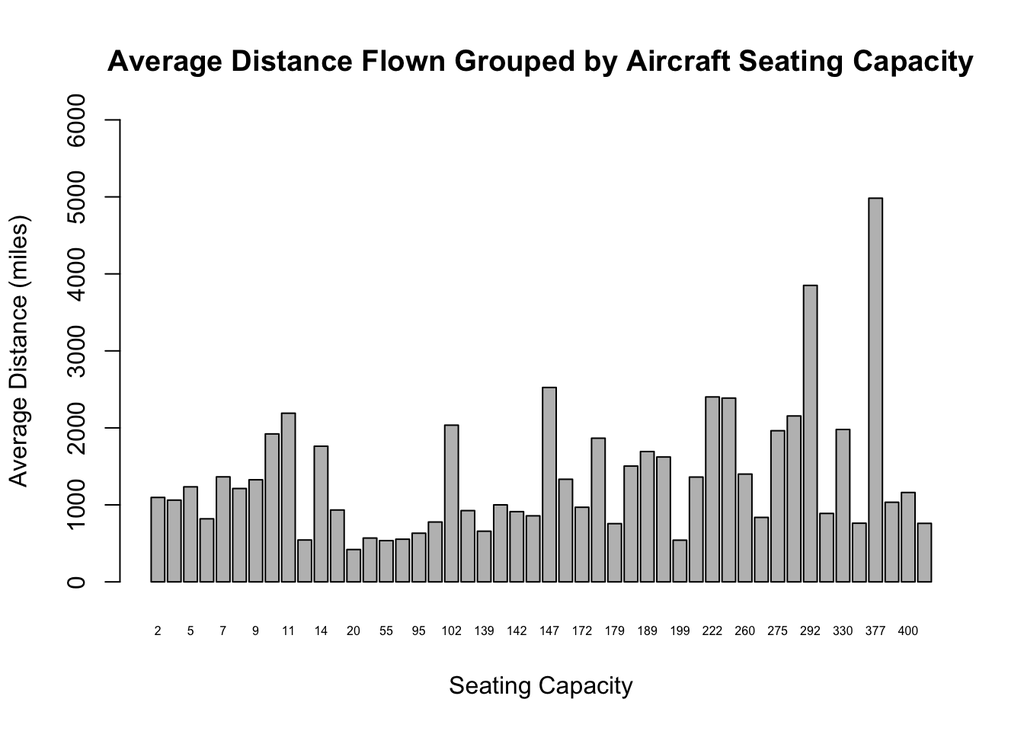

   ```r
   # Computes average flight distance for each seating capacity
   distBySeats = tapply(nycPlane$distance, nycPlane$seats, mean, na.rm = TRUE)
   barplot(distBySeats, main = "Average Distance Flown Grouped by Aircraft Seating Capacity", xlab = "Seating Capacity", ylab = "Average Distance (miles)", cex.names = 0.5, ylim = c(0,6000))
   ```

   From this plot it can be seen that there is a loose trend that higher capacity aircraft fly longer distances on average. There are definitely several exceptions to this trend.  
   c.3) Are Boeing planes delayed longer than Airbus planes?

   ```r
   # Computes the average delay by each manufacturer type
   delayByManuf = tapply(nycPlane$dep_delay, nycPlane$manufacturer, mean, na.rm = TRUE)
   # Gets the values of the delays for Boeing and Airbus
   BoeingDelay = delayByManuf[manufacturer="BOEING"]
   AirbusDelay = delayByManuf[manufacturer="AIRBUS"]
   ```

   The average delay for Boeing aircraft flying out of NYC is 11.7 minutes. The average delay for Airbus aircraft flying out of NYC is 10.9 minutes. The average delays are very similar, but technically Boeing planes are delayed longer than Airbus planes.  
   c.4) What aircraft (by tailnumber) had the most flights out of NYC? What airline operates that aircraft? What kind of aircraft is it?

   ```r
   library(dplyr)
   # Counts the number of occurrences of a tailnumber
   byTailNum <- nycPlane %>% count(tailnum)
   # Gets tail number with most flights
   mostFlightTailnum <- byTailNum[byTailNum$n == max(byTailNum$n), "tailnum"]

   # Finds the carrier associated with that tail number
   carrierMostFlight <- nycPlane[nycPlane$tailnum == mostFlightTailnum, "carrier"]
   manufMostFlight <- nycPlane[nycPlane$tailnum == mostFlightTailnum, "manufacturer"]
   modelMostFlight <- nycPlane[nycPlane$tailnum == mostFlightTailnum, "model"]
   ```

   The tailnumber with the most flights out of NYC was N711MQ, with 486 flights. The aicraft is operated by the carrier MQ. The aircraft is a G1159B manufactured by GULFSTREAM AEROSPACE.  
   c.5) What plane model has the fastest average speed on a flight originating from NYC? What is the average speed?

   ```r
   # Computes average speed of the aicraft by dividing distance by airtime in hours
   nycPlane$avgSpeed <- (nycPlane$distance/(nycPlane$air_time/60))

   # Computes average of speed by aircraft model
   avgSpeedModel <- tapply(nycPlane$avgSpeed, nycPlane$model, mean, na.rm = TRUE)

   # Gets the max speed
   maxAvgSpeed <- max(avgSpeedModel)

   # Gets model name
   modelMaxAvgSpeed <- rownames(avgSpeedModel)[which.max(avgSpeedModel)]

   # Gets manufacturer
   manufMaxAvgSpeed <- nycPlane[nycPlane$model == modelMaxAvgSpeed, "manufacturer"]
   ```

   The plane model with the fastest average speed on a flight originating from NYC is a BOEING 777-222, with an average speed of 483 mph.

### Making Your HTML Look Nice

We want our report to be good looking, professional documents. To that end, I am asking you to do the following:

- Have a floating table of contents
- Include code folding in your output. You can find more about code folding here: https://bookdown.org/yihui/rmarkdown/html-document.html#code-folding

That’s it. Once you are done, make sure everything works and knits well and then you can push your changes to the GitHub repo and uplaod the RMD flile and the html output to Canvas.

**Have Fun!**

Sanjeev